# Comparison of Different BG Architectures in the CMC

Andrea Stocco, Catherine Sibert, Holly Hake

1/31/2021

Here we will compare how three different architectures of the Basal Ganglia (BG) fit the task-based data from the Human Connectome Project with the Common Model architecture.

## Load Data

First, we load the data.

```r
ll <- read_tsv("bg_models_ll.tsv",
               col_types=cols(Task = col_character(),
                              Direct = col_double(),
                              Modulatory = col_double(),
                              Mixed = col_double()))
```

The log-likelihood values are expressed in exponential format, with the exponent being 4. So we need to multiply all value by 10,000. Also, because the log-likelihoods vary dramatically by task, we are going to transform them into relative values:

```r
lll <- ll %>%
  pivot_longer(cols=c("Direct", "Modulatory", "Mixed"),
               names_to = "Model",
               values_to = "RawLL") %>%
  mutate(LogLikelihood = 10000*RawLL) %>%
  group_by(Task) %>%
  mutate(RelativeLL = LogLikelihood - min(LogLikelihood))
```

Then, we rename the tasks so they are displayed with the “official” HCP label.

```r
lll$Task <- recode(lll$Task,
                   Emotion = "Emotion Processing",
                   Gambling = "Incentive Processing",
                   Language = "Language and Math",
                   Social = "Social Cognition",
                   Relational = "Relational Reasoning",
                   WM="Working Memory"
)
```

## Visualize Log-Likelihoods.

After doing so, we can visualize the results. We are going to assign to each model a color in the AAAS color palette.

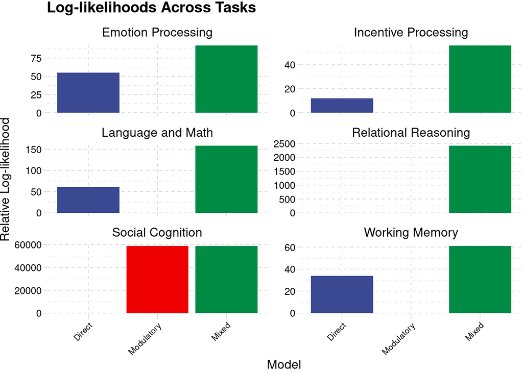

```r
pal <- pal_aaas()
z<- pal(3)[c(3,1,2)]

lll$Model <- factor(lll$Model,
                    levels = c("Direct", "Modulatory", "Mixed"))

ggplot(lll, aes(x=Model, y=RelativeLL)) +
  geom_col(aes(fill=Model)) +
  facet_wrap(~Task, scales="free_y", ncol = 2) +
  scale_fill_aaas() +
  theme_pander() +
  ggtitle("Log-likelihoods Across Tasks") +
  ylab("Relative Log-likelihood") +
  theme(axis.text.x = element_text(angle=45, hjust=1, size = 8)) +
  theme(legend.position="none")
```

## Bayes Factors

The Mixed model emerges as the best model. But is the difference significance? To objectively measure the difference in likelihoods, we are going to use Bayes Factors (BF). The BF for a model comparison They can be calculated from the difference in relative log-likelihoods (technically called $\lambda$).

```r
bf <- ll %>%
  mutate(lambda1 = 10000*(Mixed - Modulatory),
         lambda2 = 10000*(Mixed - Direct)) %>%
  mutate(BF1 = exp(lambda1),
         BF2 = exp(lambda2)) %>%
  dplyr::select(Task, lambda1, lambda2, BF1, BF2)
```

And now we can see the relative BF comparisons between the Direct and Modulatory models vs. the Mixed model. When BF > 100, it is “decisive” evidence for the better model in the comparison (according to Kass & Raftery, 1995). It is easy to see that, in all tasks, the BF largely advantages the Mixed model.

```r
bf %>%
  dplyr::select(Task, BF1, BF2) %>%
  xtable() %>%
  kable(digits = 5) %>%
  kable_styling(bootstrap_options = c("striped", "hover"))
```

| Task | BF1 | BF2 |
| --- | --- | --- |
| Emotion | 9.017628e+39 | 1.171914e+16 |
| Gambling | 2.091659e+24 | 1.285160e+19 |
| Language | 4.154590e+68 | 1.338335e+42 |
| Relational | Inf | Inf |
| Social | 2.415495e+07 | Inf |
| WM | 3.104298e+26 | 5.320482e+11 |

## Accounting for the complexity of the Mixed Model with Wilks’ Theorem

Since the three models differ also in terms of the number of parameters, it is possible that the Mixed model’s greater likelihood is due to it simply having more degrees of freedom to fit the data. Although common corrections can be applied (such as BIC and AIC) to provide a correction for the number of parameters, the fact that the Direct and Modulatory models are nested within the Mixed model allows us to use Wilks’ theorem (1938), which accounts for the different number of parameters and translates the log-likelihood difference into interpretable p-values. The theorem states that, for two models of which one is nested, the probability that the fit of the more complex is due to chance (its p-value) approximates the probability of obtaining the value of 2λ (twice the log-likelihood difference) in a χ2 distribution with degrees of freedom corresponding to the difference in the number of parameters. Using this theorem, we calculated the probability that the greater fit of the Mixed model is due to chance (note that this comparison accounts for the greater complexity of the Mixed model in the χ2 distribution).

```r
X<-c()
Y<-c()
M<-c()
P<-c()

for (task in unique(bf$Task)) {
  xmax = max(bf$lambda1[bf$Task==task],
             bf$lambda2[bf$Task==task])
  xmax <- xmax * 1.1
  x <- 1:xmax
  y1 <- dchisq(x, df=10)
  y2 <- dchisq(x, df=5)
  y1[0] <- 0
  y2[1] <- 0
  x <- c(x, x)
  y <- c(y1, y2)
  m <- c(rep("Modulatory", xmax),
         rep("Direct", xmax))
  p <- rep(task, length(m))
  X <- c(X, x)
  Y <- c(Y, y)
  M <- c(M, m)
  P <- c(P, p)
}

lwilks <- as_tibble(data.frame(x=X, y=Y, Model = M, Task = P))

lwilks$Task <- recode(lwilks$Task,
                    Emotion = "Emotion Processing",
                    Gambling = "Incentive Processing",
                    Language = "Language and Math",
                   Social = "Social Cognition",
                   Relational = "Relational Reasoning",
                   WM="Working Memory"
                   )
```

And this is what the distributions look like, on the correct scale to visualize the 2λ mark in every task.

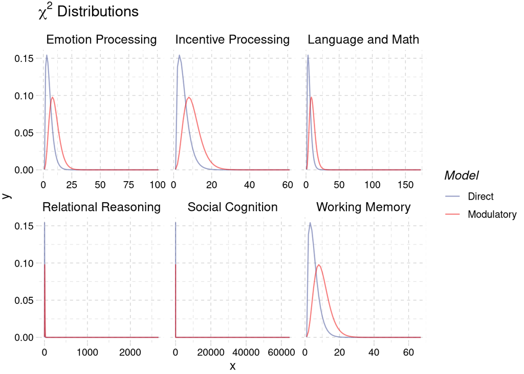

```r
ggplot(lwilks, aes(x=x, y=y, col=Model)) +
  geom_line(alpha=.5) +
  scale_color_aaas() +
  ggtitle(expression(paste(chi^2, " Distributions"))) +
  facet_wrap(~Task, scale="free_x") +
  theme_pander()
```

```r
lbf <- pivot_longer(bf,
                    cols=c("lambda1", "lambda2"),
                    names_to = "Model",
                    values_to = "Lambda") %>%
  dplyr::select(Task, Model, Lambda)

lbf$Model <- recode(lbf$Model,
                     lambda1 = "Modulatory",
                     lambda2 = "Direct")


lbf$Task <- recode(lbf$Task,
                    Emotion = "Emotion Processing",
                    Gambling = "Incentive Processing",
                    Language = "Language and Math",
                   Social = "Social Cognition",
                   Relational = "Relational Reasoning",
                   WM="Working Memory"
                   )
```

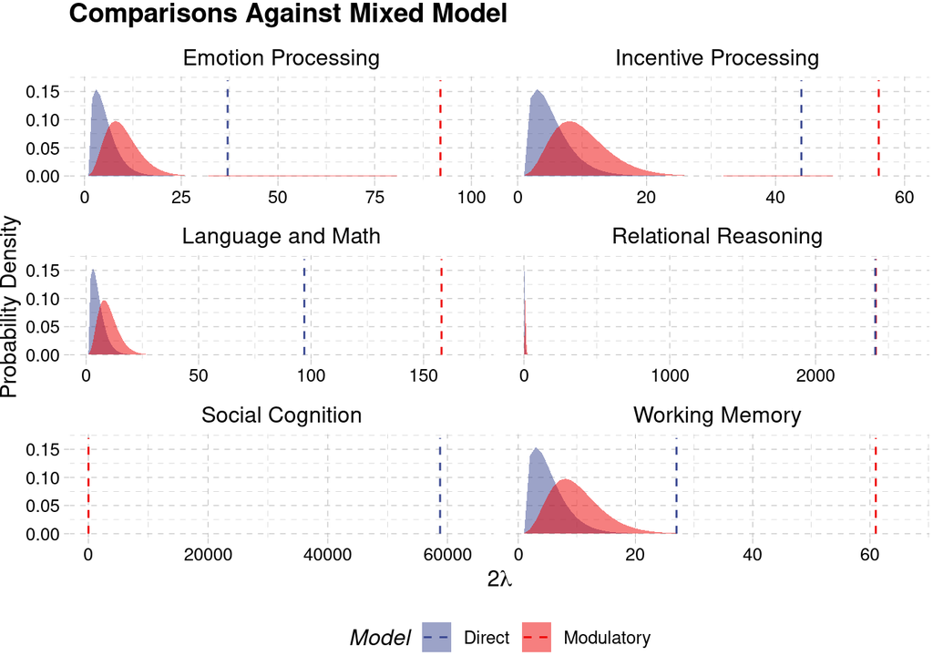

```r
ggplot(lbf, aes(x=Lambda, y=Lambda)) +
  geom_segment(aes(x=Lambda, y=0,
                   xend=Lambda, yend=0.17,
                   col=Model),
               linetype="dashed") +
  facet_wrap(~Task, scales="free_x", ncol=2) +
  geom_polygon(data=lwilks, aes(x=x, y=y, fill=Model), alpha=0.5) +
  scale_color_aaas() +
  scale_fill_aaas() +
  theme_pander() +
  ggtitle("Comparisons Against Mixed Model") +
  ylab("Probability Density") +
  xlab(expression(2*lambda)) +
  theme(legend.position = "bottom")
```